# From Unconditional to Multivariate Bayesian Model Workshop – Series 1 of 10 – Gaussian vs Robust Estimation

Biostatistics

Bayesian Methods

R

JAGS/Stan

Fitting an unconditional model (without predictors) Robust estimates – Gaussian vs. t-distribution

Hai Nguyen  
November 20, 2021

How to fitting an unconditional model (without predictors)? From here, we can see the philosophy of the Bayesian’s perspective.

## Typical response distribution

| Scale y | Dist. $y \sim f(\mu, ...)$ | Inverse link $\mu = g^{-1}(\eta)$ |
| --- | --- | --- |
| Metric | $y \sim dnorm(\mu,\sigma)$ | $\mu = \eta$ |
| Binary | $y \sim dbern(\mu)$ | $\mu = logistic(\eta)$ |
| Nominal | $y \sim dmultinom(\mu_1, ...,\mu_p)$ | $\mu_k = \frac{exp(\eta_k)}{\sum_j exp(\eta_j)}$ |
| Ordinal | $y \sim dmultinom(\mu_1, ...,\mu_p)$ | $\mu = \Phi(\frac{\theta_k - \eta}{\sigma}) - \Phi(\frac{\theta_{k-1} - \eta}{\sigma})$ |
| Count | $y \sim dpois(\mu)$ | $\mu = exp(\eta)$ |

## Fitting normal model for 1 group with no predictors

We just need to estimate both parameters of normal distribution for random variable $y$.

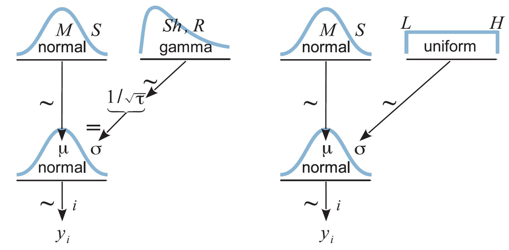

The diagram of the model structure (adapted from Textbook)

```r
# preparing data
set.seed(03172021)
y <- rnorm(100, mean = 6, sd = 3)
Ntotal = length(y)
```

Create a data list, include sample mean and standard deviation in it.

```r
dataList = list(
  y = y ,
  Ntotal = Ntotal ,
  mean_mu = mean(y) ,
  sd_mu = sd(y)
)
```

### Running in JAGS

Specify the model.

Recall that in JAGS [@RN733] normal distribution is specified by precision $\frac{1}{\sigma^2}$ instead of standard deviation or variance. Select an uninformative prior for $\sigma$ and normal (conjugate) prior for $\mu$.

What do we suggest as parameters of the normal distribution based on the sample?
$$y_i \sim N(\mu,\tau), \ \text{where} \ \tau = \frac{1}{\sigma^2} \\
\mu \sim N(M,S) \\
\sigma \sim Uniform[Lw,Mx] \ \text{OR} \ Gamma(\alpha, \beta)$$

```r
modelString = "
  model {
    for (i in 1:Ntotal) {
      y[i] ~ dnorm(mu , 1/sigma^2) #JAGS uses precision
    }
    # mu ~ dnorm(mean_mu , 1/(100*sd_mu)^2)
    mu ~ dnorm(mean_mu , Ntotal/sd_mu^2) #JAGS uses precision
    sigma ~ dunif(sd_mu/1000, sd_mu*1000)
  }
  " # close quote for modelString
```

```r
# Write out modelString to a text file
writeLines(modelString, con="data/TEMPmodel.txt")
```

Initialize chains.

```r
initsList <- function(){
   upDown <- sample(c(1,-1),1)
   m <- mean(y)*(1+upDown*.05)
   s <- sd(y)*(1-upDown*.1)
   list(mu = m, sigma = s)
}
```

Run the chains.

1. Set parameters:

```r
# Create, initialize, and adapt the model:
parameters = c("mu", "sigma")     # The parameters to be monitored
adaptSteps = 500               # Number of steps to "tune" the samplers
burnInSteps = 1000
numSavedSteps = 50000
nChains = 4
thinSteps = 1
nIter = ceiling((numSavedSteps*thinSteps)/nChains )
```

2. Send model to JAGS:

```r
jagsModel = jags.model("data/TEMPmodel.txt", data=dataList, inits=initsList,
                       n.chains=nChains, n.adapt=adaptSteps)
```

3. Burn in and run:

```r
# Burn-in:
update(jagsModel, n.iter=burnInSteps)

# Run it
# The saved MCMC chain:
codaSamples = coda.samples(jagsModel, variable.names=parameters,
                           n.iter=nIter, thin=thinSteps)
```

Check how chains converged.

```r
summary(codaSamples)
```

```
Iterations = 1501:14000
Thinning interval = 1
Number of chains = 4
Sample size per chain = 12500

1. Empirical mean and standard deviation for each variable,
   plus standard error of the mean:

       Mean     SD Naive SE Time-series SE
mu    5.923 0.2265 0.001013       0.001001
sigma 3.208 0.2325 0.001040       0.001407

2. Quantiles for each variable:

       2.5%   25%   50%   75% 97.5%
mu    5.480 5.769 5.922 6.076 6.366
sigma 2.792 3.044 3.194 3.356 3.698
```

The parameters are estimated close to what we simulated and very similar to what point estimation would give.

```r
mean(y)
```

```
[1] 5.922201
```

```r
sd(y)
```

```
[1] 3.173288
```

The plot of the samples and the densities of the parameters.

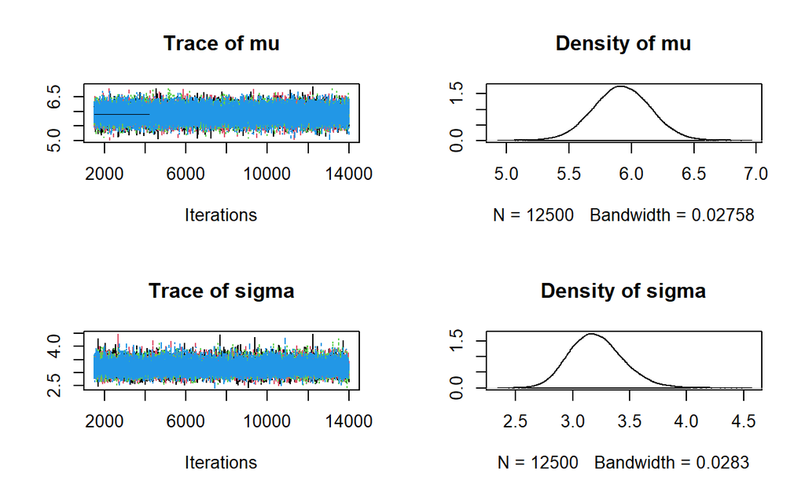

```r
plot(codaSamples)
```

Plot autocorrelations.

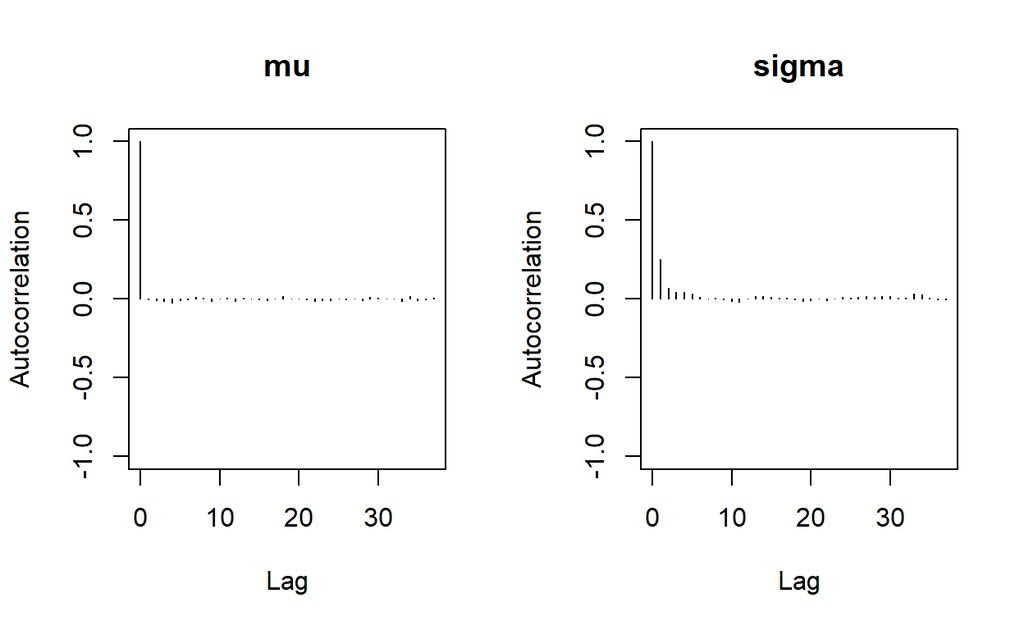

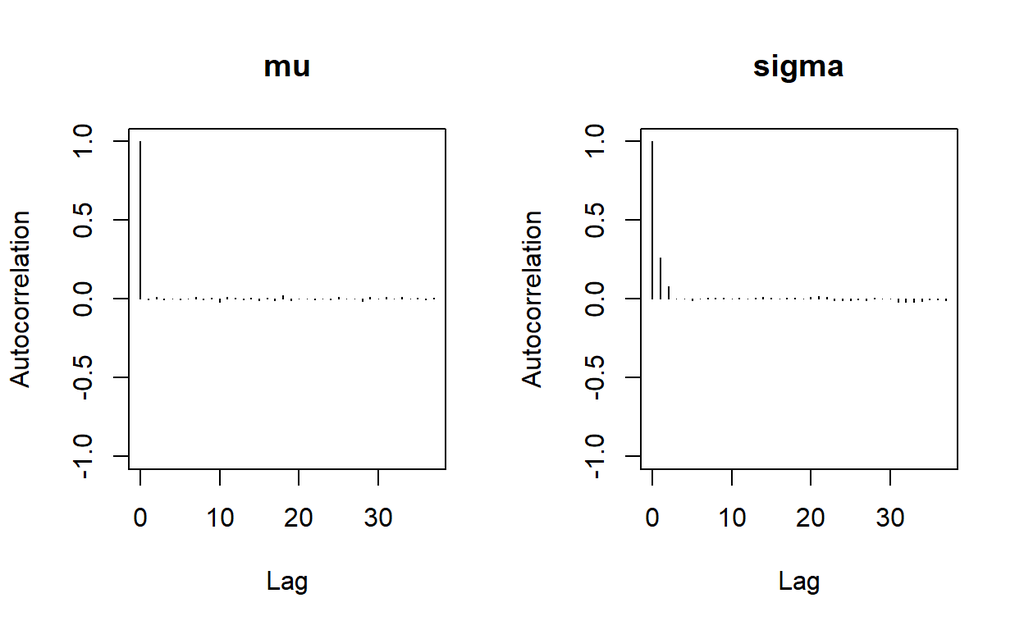

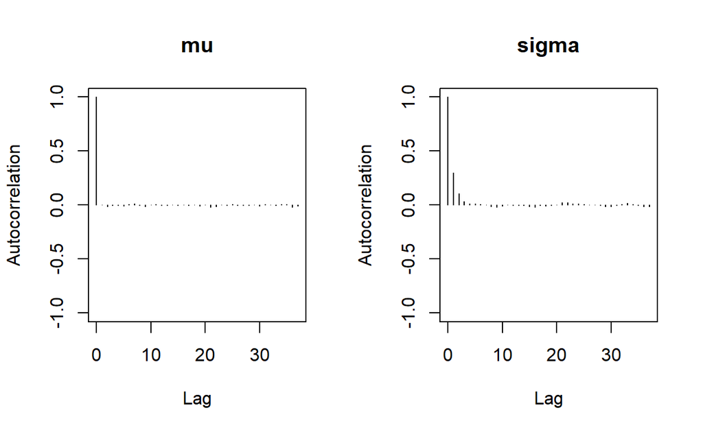

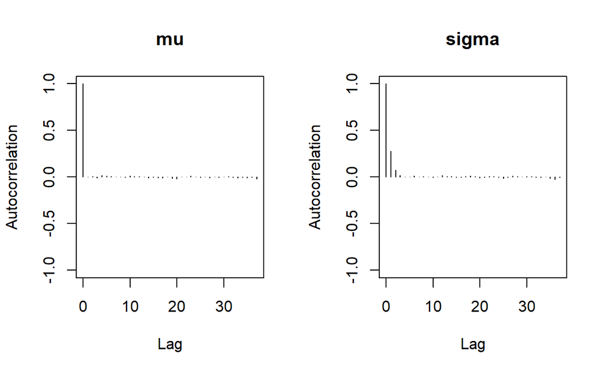

```r
autocorr.plot(codaSamples, ask = F)
```

Autocorrelation function plot shows that standard deviation effective size must be pretty small.  
In fact:

```r
effectiveSize(codaSamples)
```

```
      mu    sigma
51236.85 27414.72
```

Shrink factor shows that even with long memory for standard deviation distributions converged:

```r
gelman.diag(codaSamples)
```

```
Potential scale reduction factors:

      Point est. Upper C.I.
mu             1          1
sigma          1          1

Multivariate psrf

1
```

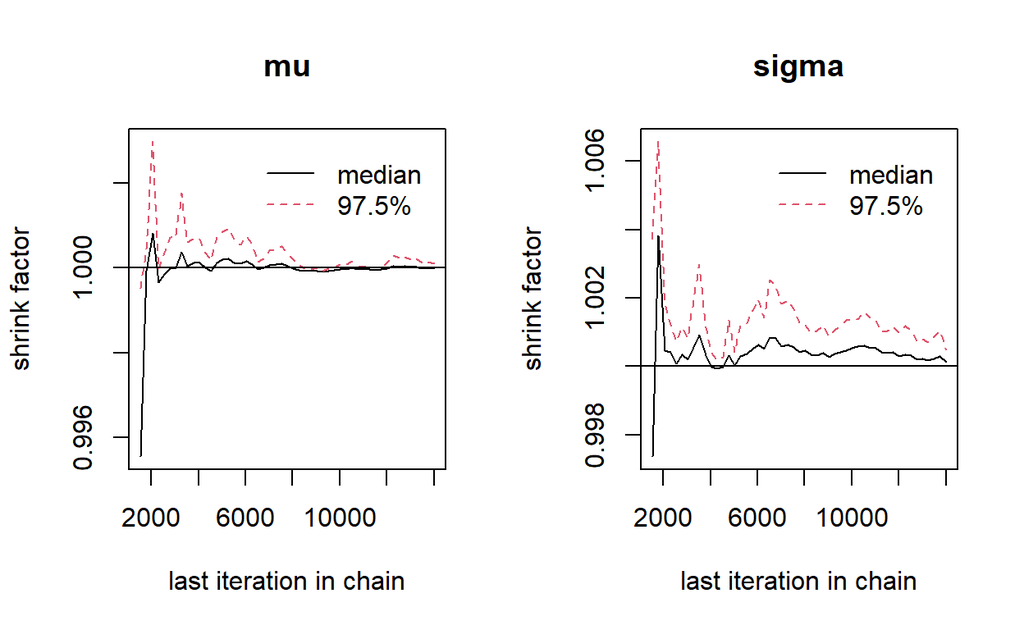

```r
gelman.plot(codaSamples)
```

Observed HDIs of the chains:

```r
lapply(codaSamples,function(z) hdi(as.matrix(z)))
```

```
[[1]]
            mu    sigma
lower 5.479068 2.774907
upper 6.362111 3.677393
attr(,"credMass")
[1] 0.95

[[2]]
            mu    sigma
lower 5.488275 2.766543
upper 6.367365 3.661088
attr(,"credMass")
[1] 0.95

[[3]]
            mu    sigma
lower 5.475716 2.778049
upper 6.353808 3.677524
attr(,"credMass")
[1] 0.95

[[4]]
            mu    sigma
lower 5.489742 2.782062
upper 6.386876 3.677348
attr(,"credMass")
[1] 0.95
```

### Running in Stan

```r
modelString = "
data {
    int<lower=1> Ntotal;
    real y[Ntotal];
    real mean_mu;
    real sd_mu;
}
transformed data {
    real unifLo;
    real unifHi;
    real normalSigma;
    unifLo = sd_mu/100;
    unifHi = sd_mu*100;
    normalSigma = sd_mu*100;  // 100*10 times larger than MLE
}
parameters {
    real mu;
    real<lower=0> sigma;
}
model {
    sigma ~ uniform(unifLo, unifHi);
    mu ~ normal(mean_mu, normalSigma);
    y ~ normal(mu, sigma);
}
" # close quote for modelString
```

Create a DSO and save it to disk to reuse later or just keep it in memory.

```r
stanDso <- stan_model(model_code = modelString)
```

Run chains by either using the existing DSO:

```r
stanFit <- sampling(object=stanDso,
                    data = dataList,
                    pars=c('mu', 'sigma'),
                    chains = 2,
                    cores= 2,
                    iter = 5000,
                    warmup = 200,
                    thin = 1)
```

```r
# fit model
fit <- stan(file = "modelString.stan",
            data = list(Ntotal = length(y),
                        y = y,
                        meanY=mean(y),
                        sdY=sd(y)),
            pars=c('mu', 'sigma'),
            # control=list(adapt_delta=0.99),
            iter=5000, chains = 2, cores = 2
            )
```

Objects `fit` and `stanFit` should return very similar results. The difference between `stan()` and `sampling()` is in the argument `object` which is DSO. If you expect to repeat same calculations with different data compiling a DSO and reusing it with `sampling()` is faster.

```r
# text statistics:
print (stanFit)
```

```
Inference for Stan model: anon_model.
2 chains, each with iter=5000; warmup=200; thin=1;
post-warmup draws per chain=4800, total post-warmup draws=9600.

         mean se_mean   sd    2.5%     25%     50%     75%   97.5%
mu       5.92    0.00 0.32    5.30    5.71    5.92    6.14    6.57
sigma    3.22    0.00 0.23    2.80    3.06    3.20    3.36    3.72
lp__  -164.84    0.02 1.01 -167.54 -165.23 -164.53 -164.11 -163.85
      n_eff Rhat
mu     8953    1
sigma  7630    1
lp__   4176    1

Samples were drawn using NUTS(diag_e) at Thu Feb 23 20:07:56 2023.
For each parameter, n_eff is a crude measure of effective sample size,
and Rhat is the potential scale reduction factor on split chains (at
convergence, Rhat=1).
```

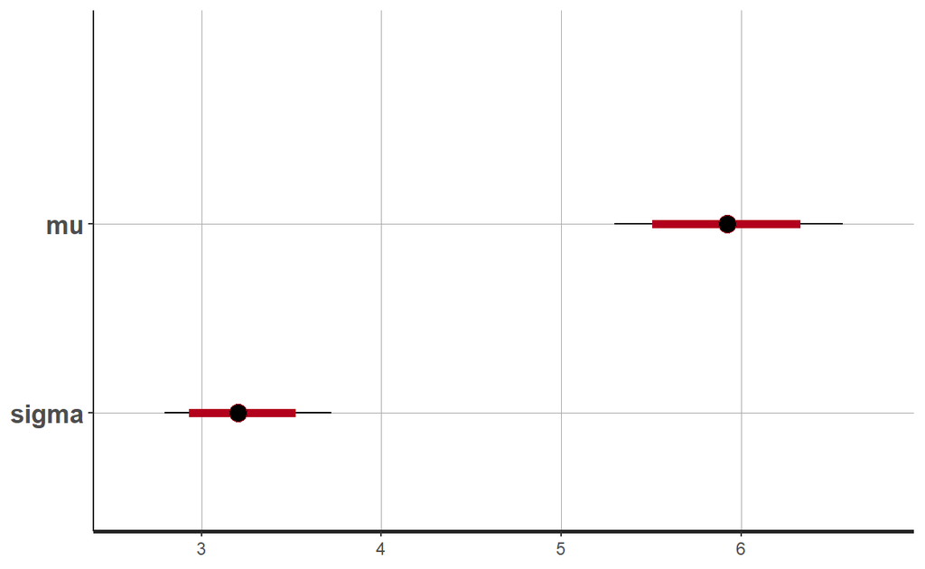

```r
# estimates & hdi:
plot(stanFit)
```

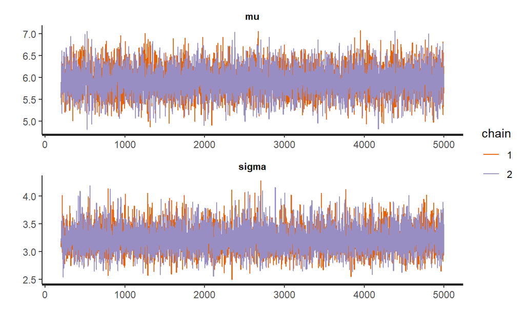

```r
# samples
traceplot(stanFit, ncol=1, inc_warmup=F)
```

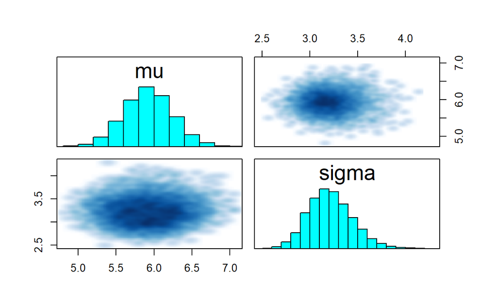

```r
pairs(stanFit, pars=c('mu','sigma'))
```

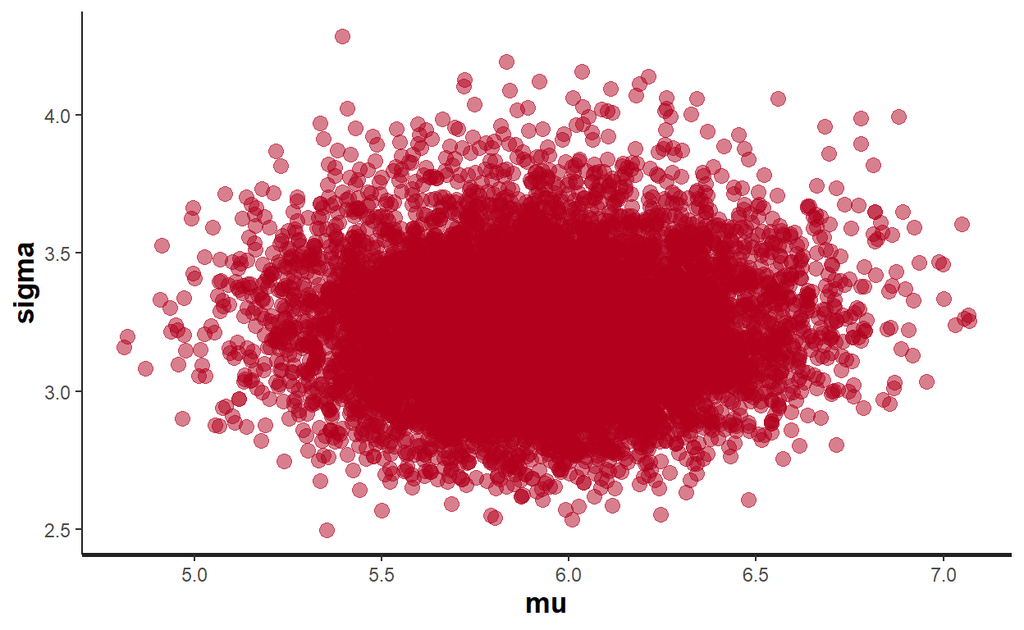

```r
stan_scat(stanFit, c('mu', 'sigma'))
```

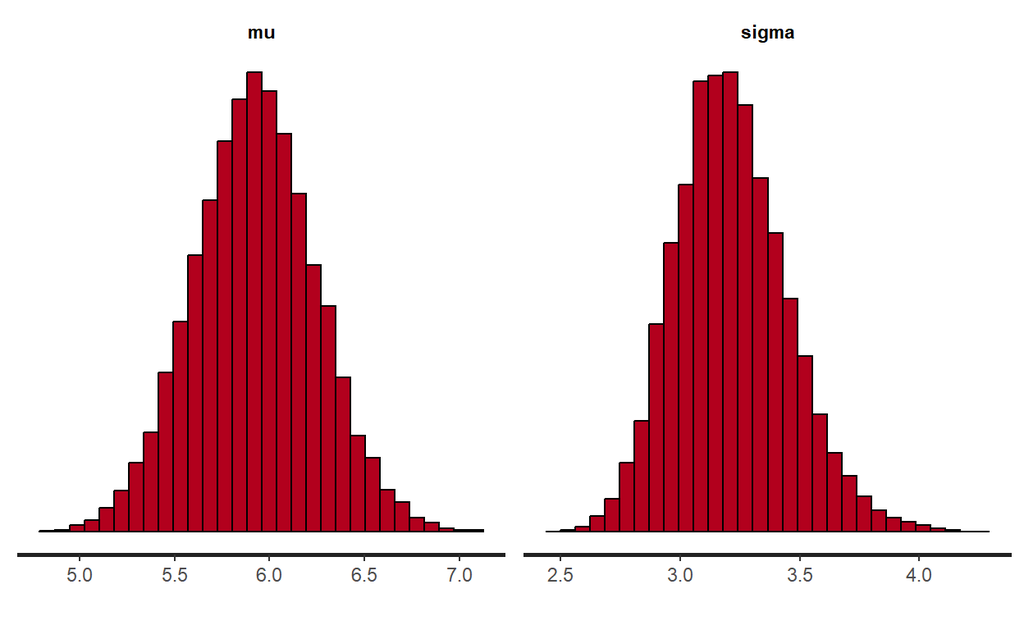

```r
stan_hist(stanFit)
```

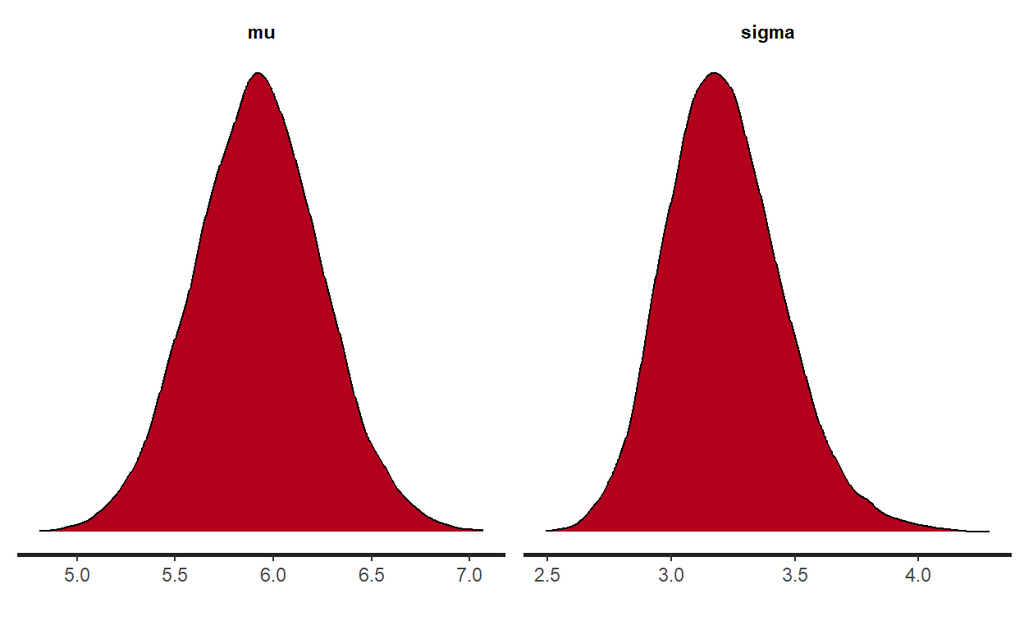

```r
stan_dens(stanFit)
```

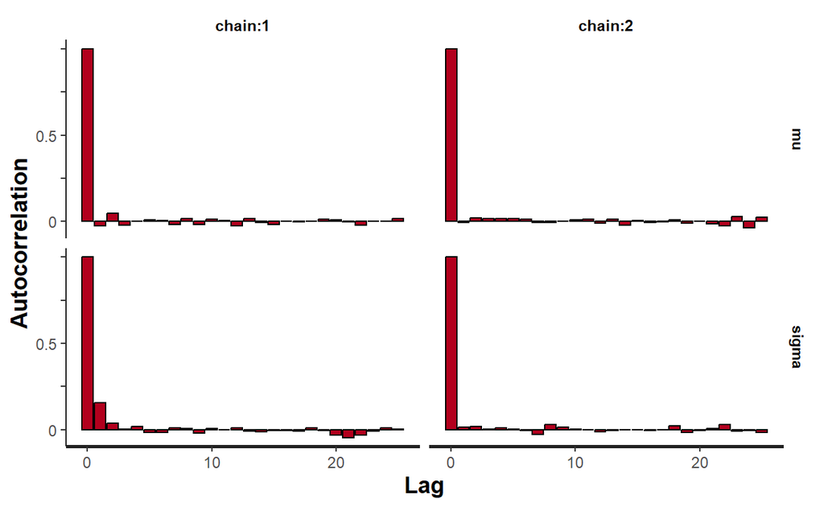

```r
# autocorrelation:
stan_ac(stanFit, separate_chains = T)
```

```r
# or work with familiar coda class:
stan2coda <- function(fit) {
    # apply to all chains
    mcmc.list(lapply(1:ncol(fit), function(x) mcmc(as.array(fit)[,x,])))
}
codaSamples <- stan2coda(stanFit)
summary(codaSamples)
```

```
Iterations = 1:4800
Thinning interval = 1
Number of chains = 2
Sample size per chain = 4800

1. Empirical mean and standard deviation for each variable,
   plus standard error of the mean:

          Mean     SD Naive SE Time-series SE
mu       5.923 0.3225 0.003291       0.003330
sigma    3.216 0.2344 0.002392       0.002609
lp__  -164.839 1.0128 0.010337       0.015893

2. Quantiles for each variable:

          2.5%      25%      50%      75%    97.5%
mu       5.298    5.707    5.922    6.137    6.566
sigma    2.795    3.055    3.201    3.364    3.720
lp__  -167.540 -165.228 -164.526 -164.113 -163.847
```

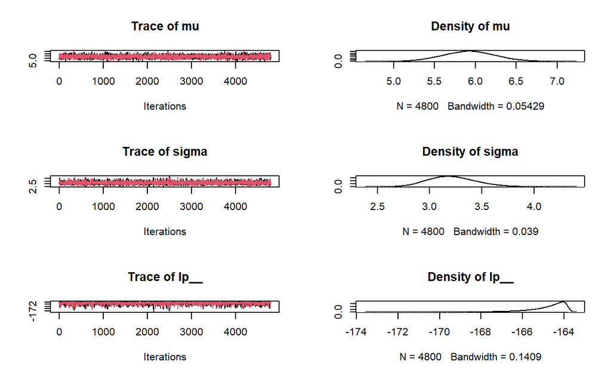

```r
plot(codaSamples)
```

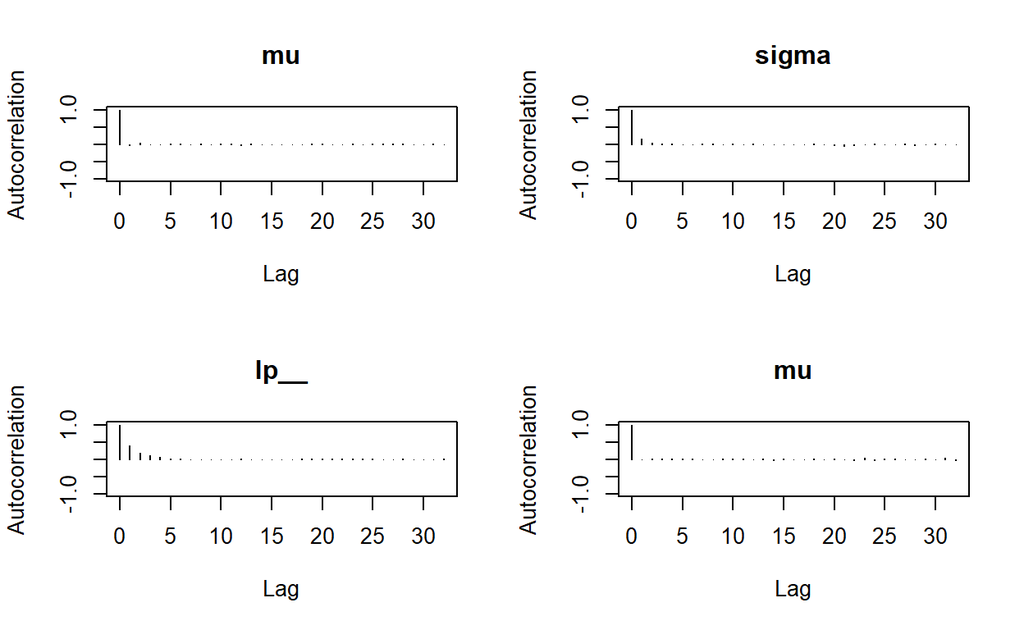

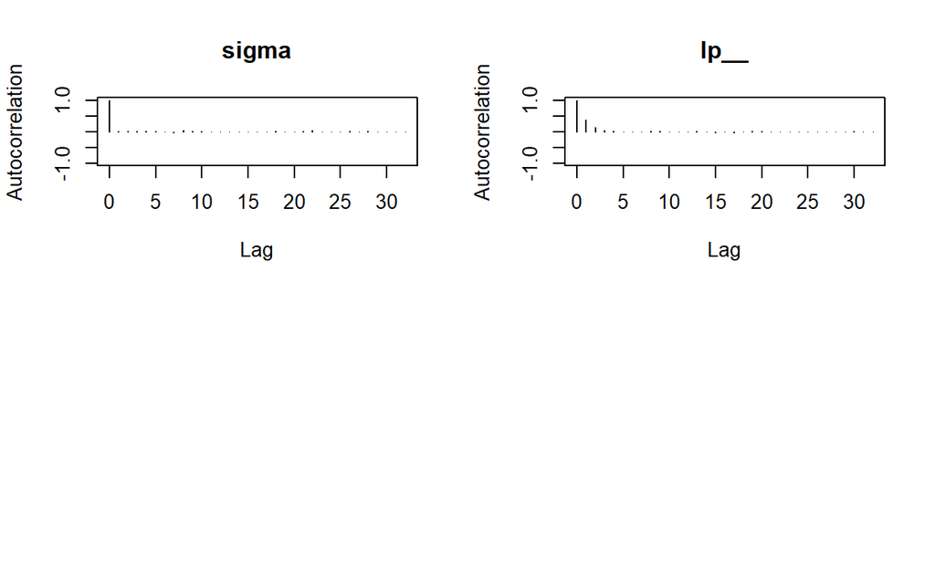

```r
autocorr.plot(codaSamples)
```

```r
effectiveSize(codaSamples)
```

```
      mu    sigma     lp__
9392.909 8296.156 4092.009
```

```r
gelman.diag(codaSamples)
```

```
Potential scale reduction factors:

      Point est. Upper C.I.
mu             1       1.00
sigma          1       1.00
lp__           1       1.01

Multivariate psrf

1
```

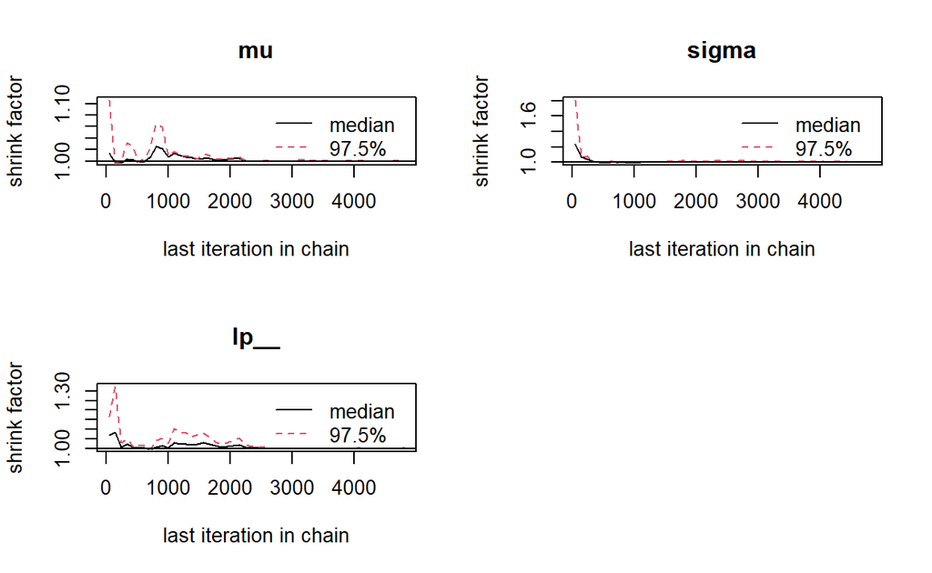

```r
gelman.plot(codaSamples)
```

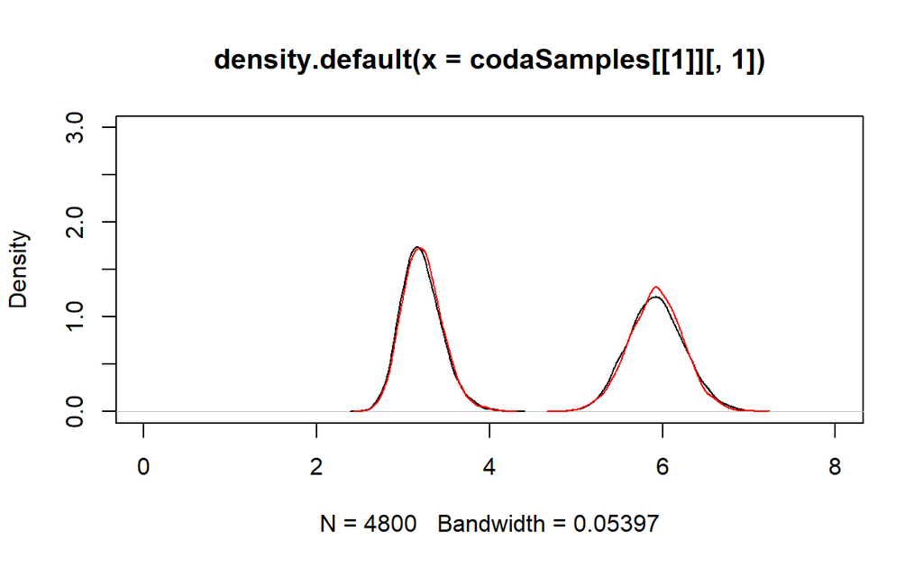

```r
plot(density(codaSamples[[1]][,1]),xlim=c(0,8),ylim=c(0,3))  # mu, 1st chain
lines(density(codaSamples[[1]][,2]))                         # sigma, 1st chain
lines(density(codaSamples[[2]][,1]),col="red")               # mu, 2nd chain
lines(density(codaSamples[[2]][,2]),col="red")               # sigma, 2nd chain
```

Or you can use shinystan to do similar analysis of fitted model:

```r
launch_shinystan(fit)
```

## Robust estimation using t-distribution

Create a sample with heavy tails in order to check robust estimation of parameters of normal distribution.

Refer this simulation of [Leptokurtic Distributions](https://www.investopedia.com/terms/l/leptokurtic.asp).

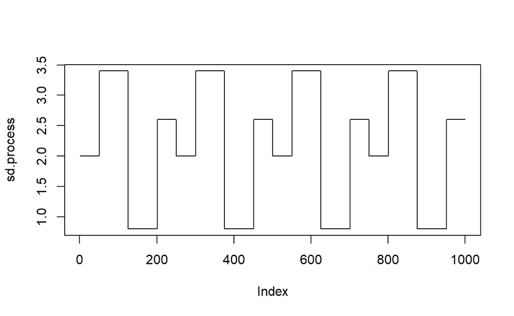

```r
nSample<-1000
sd.Values<-c(2,3.4,.8,2.6)
sd.process<-rep(c(rep(sd.Values[1],50),
                  rep(sd.Values[2],75),
                  rep(sd.Values[3],75),
                  rep(sd.Values[4],50)), 4)

plot(sd.process,type="l")
```

Variable `sd.process` is a deterministically changing standard deviation. Simulating perfect normal and independent realizations with such different standard deviations make a leptokurtic distribution.

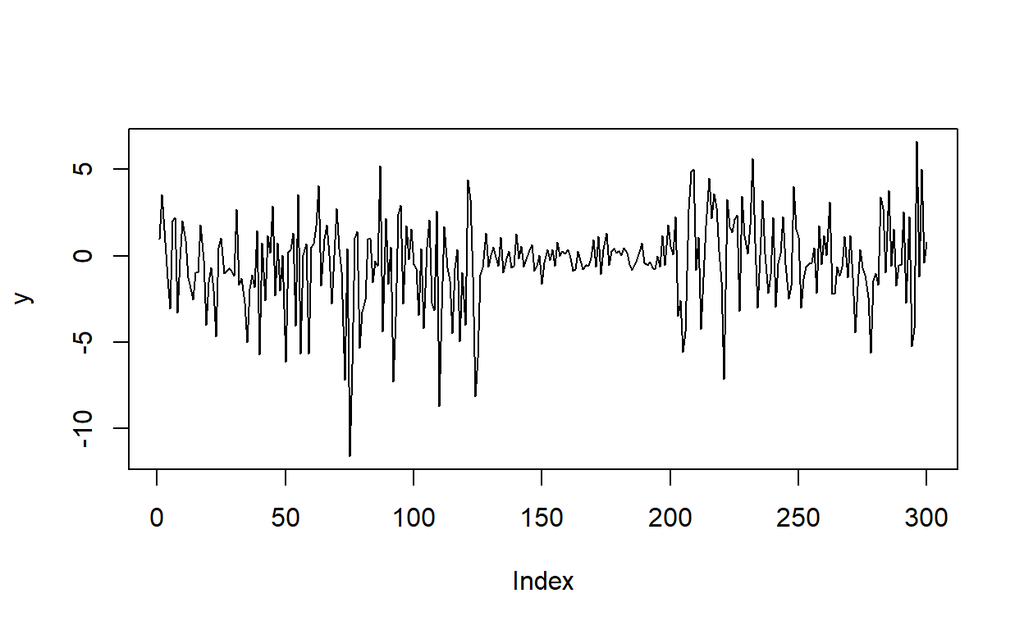

```r
set.seed(05062022)
y <- rnorm(nSample)*sd.process
y <- y[1:300]
plot(y, type="l")
```

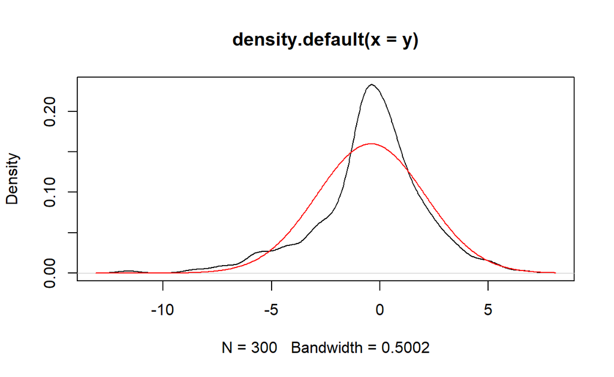

```r
den <- density(y)
plot(den)
lines(den$x, dnorm(den$x, mean(y), sd(y)), col="red")
```

```r
Ntotal = length(y)
```

Density plot clearly shows fat tails that will be most likely identified as outliers under the assumption of normal distribution.

Create data list.

```r
dataList = list(
   y = y ,
   Ntotal = Ntotal ,
   mean_mu = mean(y) ,
   sd_mu = sd(y)
   )
```

### Generalized Student distribution

Student distribution with $\nu$ degrees of freedom appears in a sampling scheme from Gaussian distribution with unknown mean and variance.

In such case the variable
$$X \sim N(\mu,
\sigma)$$
has the $z$-score
$$z = \frac{X - \hat{\mu}}{s/\sqrt{n}} =
\frac{X - \hat{\mu}}{\hat{\sigma}}$$
where $s^2 = \frac{1}{n-1} \sum_{i=1}^n (X_i - \hat{\mu})^2$, has
$t$-distribution with $n-1$ degrees of freedom.

Then random variable
$$X = \hat{\mu} +
\hat{\sigma}z$$

- $\hat{\mu}$ - location
- $\hat{\sigma}$ - scale
- $\nu$ - amount of mass in the tails.

### JAGS

```r
modelString = "
model {
   for ( i in 1:Ntotal ) {
      y[i] ~ dt(mu,1/sigma^2,nu)
   }
   mu ~ dnorm( mean_mu , 100/sd_mu^2 )
   sigma ~ dunif( sd_mu/1000 , sd_mu*1000 )
   nu ~ dexp(1/30.0)
}
" # close quote for modelString
# Write out modelString to a text file
writeLines(modelString , con="data/TEMPmodel-jags.txt")
```

Initialize the model with MLE.

```r
initsList <-function() {
   upDown<-sample(c(1,-1),1)
   m <- mean(y)*(1+upDown*.05)
   s <- sd(y)*(1-upDown*.1)
   list(mu = m, sigma = s, nu=2)
   }
```

```r
parameters = c("mu", "sigma", "nu")     # The parameters to be monitored
adaptSteps = 500               # Number of steps to "tune" the samplers
burnInSteps = 1000
nChains = 3
thinSteps = 1
numSavedSteps=50000
(nIter = ceiling((numSavedSteps*thinSteps)/nChains))
```

```
[1] 16667
```

```r
# Create, initialize, and adapt the model:
jagsModel = jags.model("data/TEMPmodel-jags.txt", data=dataList, inits=initsList,
                       n.chains=nChains, n.adapt=adaptSteps )
```

Run the chains.

```r
# Burn-in:
update(jagsModel, n.iter=burnInSteps)
# The saved MCMC chain:
codaSamples = coda.samples(jagsModel, variable.names=parameters ,
                           n.iter=nIter, thin=thinSteps)
```

Explore the results.

```r
summary(codaSamples)
```

```
Iterations = 1501:18167
Thinning interval = 1
Number of chains = 3
Sample size per chain = 16667

1. Empirical mean and standard deviation for each variable,
   plus standard error of the mean:

         Mean     SD  Naive SE Time-series SE
mu    -0.2816 0.1115 0.0004988      0.0006814
nu     4.1298 1.5167 0.0067826      0.0223954
sigma  1.8116 0.1673 0.0007482      0.0021333

2. Quantiles for each variable:

         2.5%     25%     50%     75%    97.5%
mu    -0.5031 -0.3565 -0.2804 -0.2055 -0.06739
nu     2.3196  3.1388  3.7905  4.7075  7.98449
sigma  1.5018  1.6962  1.8053  1.9221  2.15579
```

```r
mean(y)
```

```
[1] -0.4222642
```

```r
sd(y)
```

```
[1] 2.495025
```

Note that the robust estimate of $\mu$ is similar, but $\sigma$ is significantly smaller.

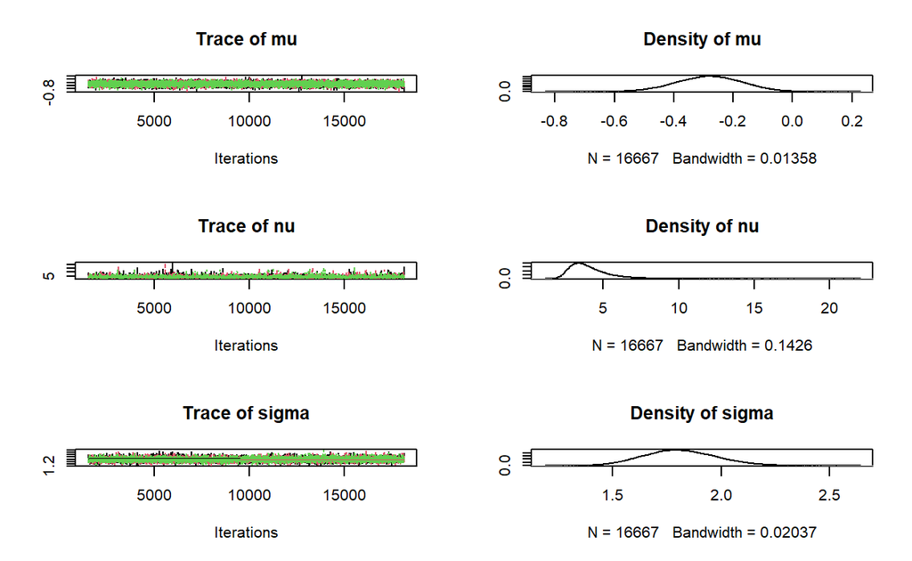

```r
plot(codaSamples)
```

```r
summary(sd.process)
```

```
   Min. 1st Qu.  Median    Mean 3rd Qu.    Max.
   0.80    0.80    2.30    2.18    3.40    3.40
```

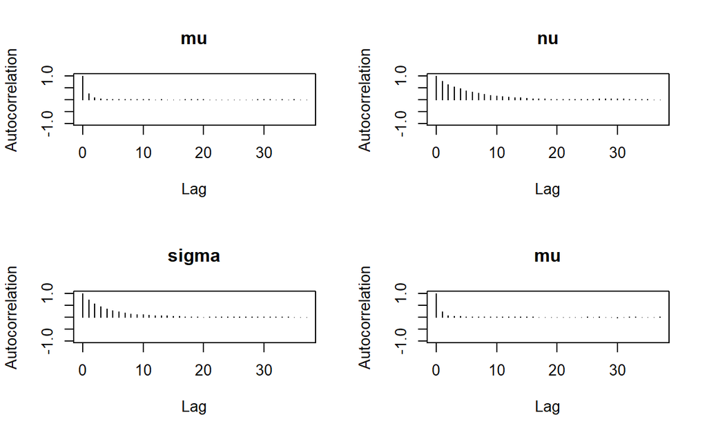

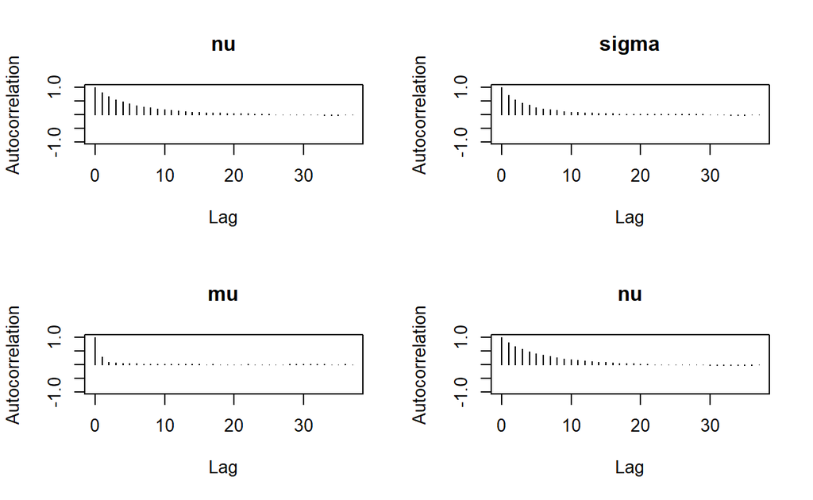

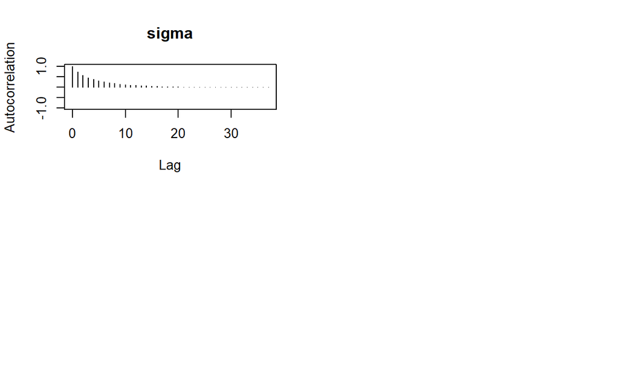

```r
autocorr.plot(codaSamples,ask=F)
```

```r
effectiveSize(codaSamples)
```

```
       mu        nu     sigma
26967.896  4580.058  6146.000
```

```r
gelman.diag(codaSamples)
```

```
Potential scale reduction factors:

      Point est. Upper C.I.
mu             1       1.00
nu             1       1.01
sigma          1       1.00

Multivariate psrf

1
```

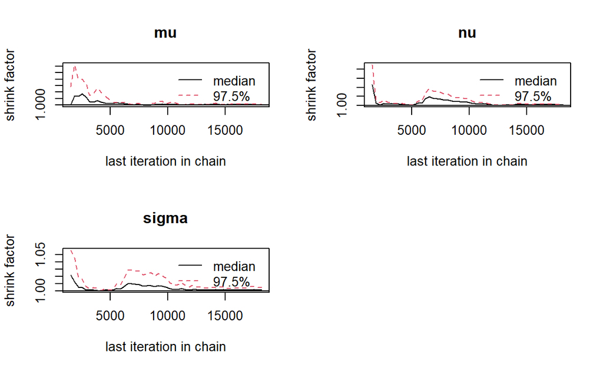

```r
gelman.plot(codaSamples)
```

```r
head(codaSamples[1])
```

```
[[1]]
Markov Chain Monte Carlo (MCMC) output:
Start = 1501
End = 1507
Thinning interval = 1
              mu       nu    sigma
[1,] -0.35538534 4.495681 1.958775
[2,] -0.06611877 4.258681 1.793895
[3,] -0.05521260 4.103952 1.789491
[4,] -0.24838098 5.631748 1.801702
[5,] -0.24537268 4.109628 1.863111
[6,] -0.19055382 3.354896 2.028280
[7,] -0.56653077 4.627866 1.839904

attr(,"class")
[1] "mcmc.list"
```

```r
(HDIofChains<-lapply(codaSamples,function(z) hdi(as.matrix(z))))
```

```
[[1]]
              mu       nu    sigma
lower -0.5047759 2.070184 1.501770
upper -0.0678133 7.153532 2.149501
attr(,"credMass")
[1] 0.95

[[2]]
               mu       nu    sigma
lower -0.49556250 2.028008 1.475841
upper -0.07011458 6.820492 2.127922
attr(,"credMass")
[1] 0.95

[[3]]
               mu       nu    sigma
lower -0.50150501 1.966809 1.497709
upper -0.06232077 6.961558 2.143415
attr(,"credMass")
[1] 0.95
```

Non-robust estimate of $\sigma$ is outside the HDI for all the chains.

### Stan

Adapt the model description to t-distribution with additional parameter $\nu$.

```r
modelString = "
data {
    int<lower=1> Ntotal;
    real y[Ntotal];
    real mean_mu;
    real sd_mu;
}
transformed data {
    real unifLo;
    real unifHi;
    real normalSigma;
    real expLambda;         //New: parameter of prior for nu
    unifLo = sd_mu/1000;
    unifHi = sd_mu*1000;
    normalSigma = sd_mu*100;
    expLambda=1/29.0;      //New: setting value for expLambda
}
parameters {
    real<lower=0> nuMinusOne; //New: definition of additional parameter nu
    real mu;
    real<lower=0> sigma;
}
transformed parameters {
    real<lower=0> nu;           //New: new parameter nu
    nu=nuMinusOne+1;           //New: shifting nu to avoid zero
}
model {
    sigma ~ uniform(unifLo, unifHi);
    mu ~ normal(mean_mu, normalSigma);
    nuMinusOne~exponential(expLambda);      //New: exponential prior for nu
    y ~ student_t(nu, mu, sigma);           //New: student_t distribution for nu
}
" # close quote for modelString
```

Create DSO.

```r
stanDso <- stan_model(model_code = modelString)
```

Run MCMC.

```r
stanFitRobust <- sampling(object=stanDso ,
                     data = dataList ,
                     pars=c('nu','mu', 'sigma'),
                     chains = 3,
                     cores= 3,
                     iter = 50000,
                     warmup = 300,
                     thin = 1)
```

Explore the results.

```r
# text statistics:
print(stanFitRobust)
```

```
Inference for Stan model: anon_model.
3 chains, each with iter=50000; warmup=300; thin=1;
post-warmup draws per chain=49700, total post-warmup draws=149100.

         mean se_mean   sd    2.5%     25%     50%     75%   97.5%
nu       4.04    0.01 1.54    2.30    3.10    3.72    4.58    7.69
mu      -0.24    0.00 0.12   -0.49   -0.33   -0.24   -0.16    0.00
sigma    1.80    0.00 0.16    1.50    1.69    1.80    1.91    2.14
lp__  -514.38    0.01 1.26 -517.67 -514.95 -514.05 -513.46 -512.95
      n_eff Rhat
nu    45883    1
mu    87613    1
sigma 62456    1
lp__  54355    1

Samples were drawn using NUTS(diag_e) at Thu Feb 23 20:11:46 2023.
For each parameter, n_eff is a crude measure of effective sample size,
and Rhat is the potential scale reduction factor on split chains (at
convergence, Rhat=1).
```

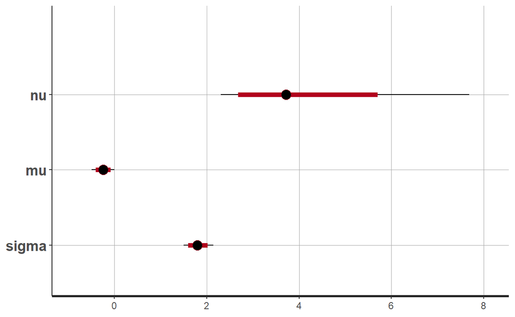

```r
# estimates & hdi:
plot(stanFitRobust)
```

```r
# samples
class(stanFitRobust)
```

```
[1] "stanfit"
attr(,"package")
[1] "rstan"
```

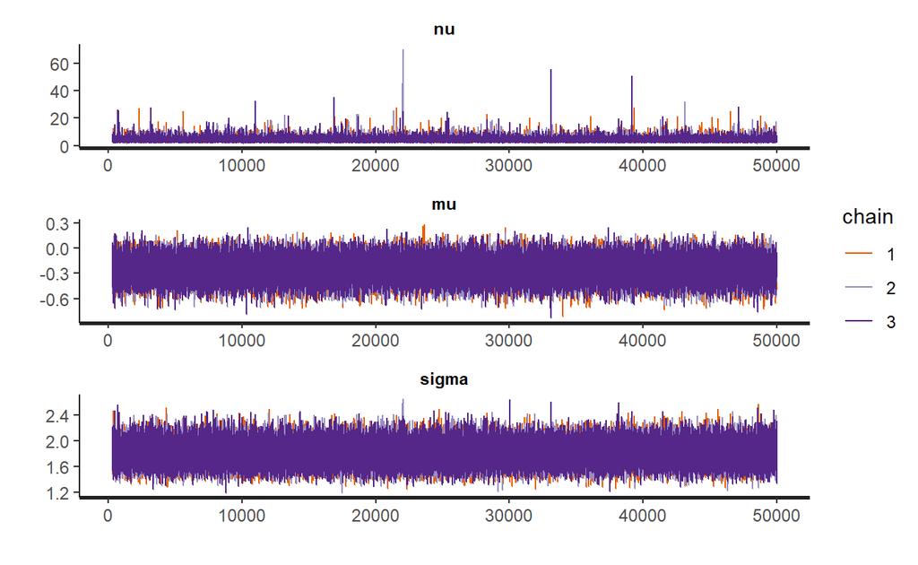

```r
rstan::traceplot(stanFitRobust, ncol=1, inc_warmup=F)
```

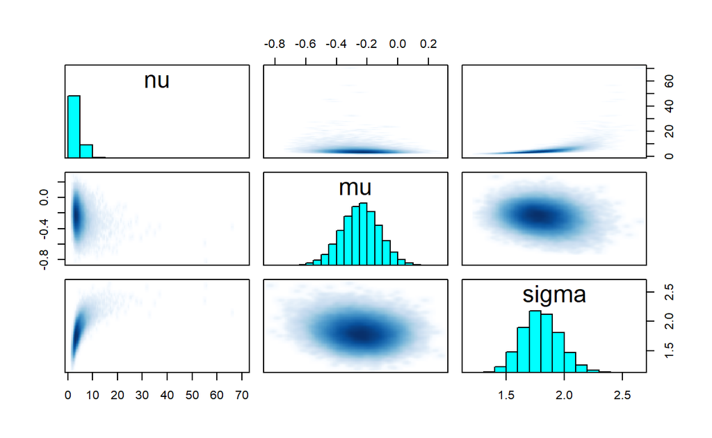

```r
pairs(stanFitRobust, pars=c('nu','mu','sigma'))
```